# Support Vector Machines for Classification

```r
library(tidyverse)
library(tidymodels)
library(janitor)
tidymodels_prefer() # Resolves conflicts, prefers tidymodel functions
```

We’re going to load again the breast cancer classification data set:

```r
patients <- read.csv("breast-cancer.csv") %>%
  clean_names() %>%
  mutate(
    class = factor(class),
    bland_chromatin = as.double(bland_chromatin),
    single_epithelial_cell_size = as.double(single_epithelial_cell_size)
  )
```

**Exercise 0.** Create a new section in your markdown file for the previous activity, called “SVMs for classification”.

**Exercise 1.** Split the data into training and test sets. Create a model specification of a linear support vector classifier using `svm_poly`. You will need to install and load the `kernlab` package. Set the degree parameter to `tune()`.

**Exercise 2.** Create a recipe to that predicts `class` by `bland_chromatin` and `single_epithelial_cell_size`. Make sure to normalize the data. Name your recipe `svm_rec`.

**Exercise 3.** Add your recipe and model to a workflow. Use 10 fold cross-validation to tune the `degree` parameter.

**Exercise 4.** Finalize the workflow with the best degree parameter, then fit the model and name it `svm_fit`. What was the best degree according to the AUC metric?

[figure not shown]

```r
autoplot(svm_res)
```

Here is an unsophisticated way to get a look at the decision boundary: First, I created a grid of points, then used the model to make predictions for each point, then plotted each point, colored by predicted class. The red region is classified as 0 (no cancer) while the blue region is classified as 1 (cancer).

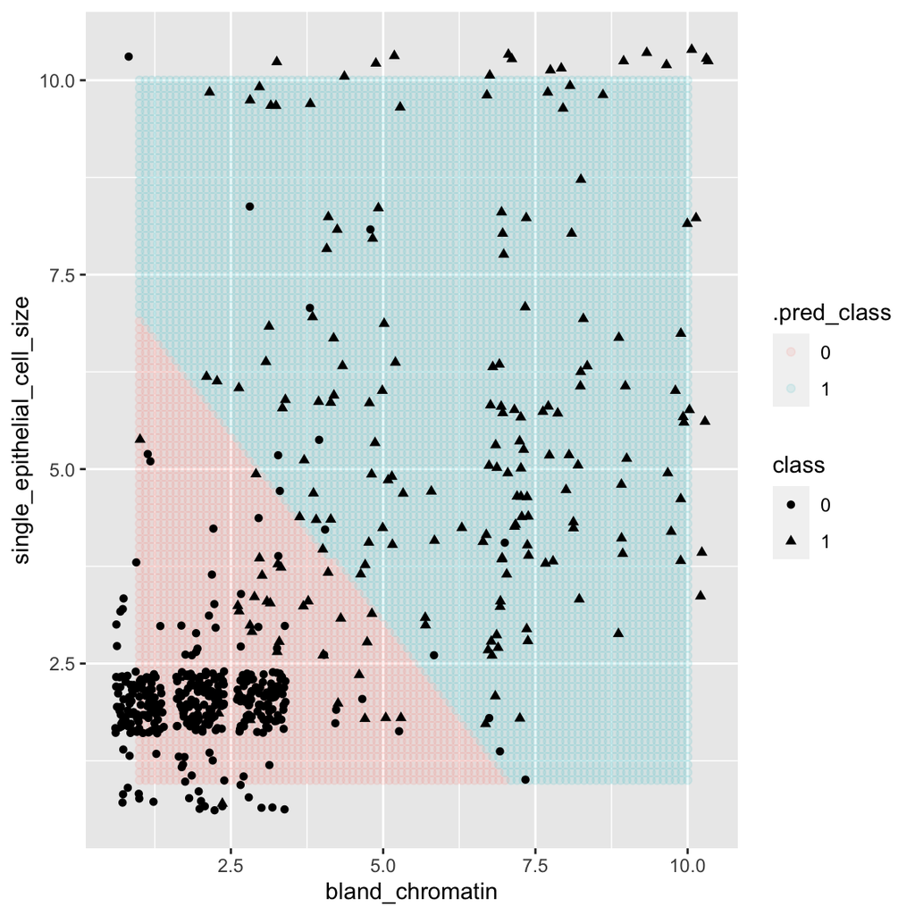

```r
expand_grid(
  bland_chromatin = seq(1, 10, by=.1),
  single_epithelial_cell_size = seq(1, 10, by=.1)
) %>%
  augment(svm_fit, .) %>%
  ggplot(aes(x=bland_chromatin, y=single_epithelial_cell_size)) +
  geom_point(aes( color=.pred_class), alpha=.1) +
  geom_point(data=patients_train, aes(shape=class), position="jitter")
```